# Transboundary Fisheries Management Under Climate Change

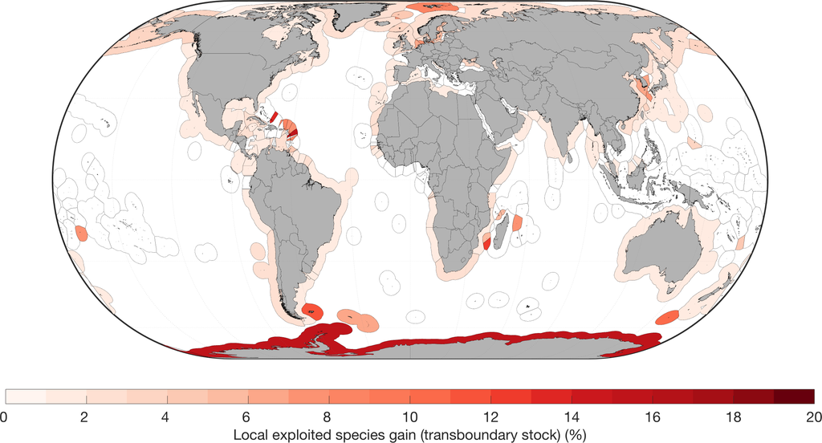

DOI: 10.1126/science.aat2360

Climate change is driving shifts in distribution of fish stocks towards areas with cooler environment, generally in higher latitude or deeper water. Particularly, distribution shifts in fish stocks that straddle between national jurisdictions or Exclusive Economic Zones (EEZ) are challenging transboundary fisheries management. Using both global and regional examples, my research aims to answer the following questions:

- Are transboundary fisheries management programs prepared for shifting stocks?
- How can we adapt to shifting stocks?
- What management schemes will be better fitted to shifting stocks?

## Working Papers

- **Palacios-Abrantes J.**, Sumaila R., Cheung W.L. Future Scenarios for Transboundary Fisheries Management in Changing Oceans: Gauging the Biological Tides

## Publications

- Malin L. Pinsky, Reygondeau G., Caddell R., **Palacios-Abrantes J.**, Spijkers J., Cheung W.L (2018) Preparing ocean governance for species on the move. *Science*, Vol. 360, Issue 6394, pp. 1189-1191, DOI: 10.1126/science.aat2360

[Full Paper](https://www.julianopalacios.com/Original_Articles/Pinsky_etal_2018.pdf) [Artículo en Español](https://www.julianopalacios.com/Translations/Border_Crossing_Esp.html)

## News

- National Geographic
- [University of British Columbia](https://science.ubc.ca/news/climate-change-has-fish-migrating-faster-regulations-can-keep)
- [University of British Columbia, French](http://pinsky.marine.rutgers.edu/wp-content/uploads/2018/06/Science-Policy-Forum_FINAL_FRENCH.pdf)
- [Washington Post](https://www.washingtonpost.com/news/speaking-of-science/wp/2018/06/14/climate-change-is-moving-fish-around-faster-than-laws-can-handle-study-says/?noredirect=on&utm_term=.ef8d0372e603)

[Back to Research](https://www.julianopalacios.com/Research.html) [Previous Project](https://www.julianopalacios.com/Projects/Metamares.html)

**Contact**